# LAPORAN UJI COBA PRAKTIKUM KECERDASAN KOMPUTASIONAL

#### Nama : Abdan Hafidz

#### NRP : 5054231021

## Import Library yang dibutuhkan

```python
from utils import *
from logic import *
from notebook import psource
```

```python
import agents as a
```

# Defining Symbolx

In my practice, i'll consider to use two boolean variables (P and Q) and define in as propotitional symbol with `symbols` syntax.

```python
(P,Q) = symbols('P,Q')
```

# Propotitional Expression with Operand &, |, =>, <=>, ^

```python
conjunction = P & Q
disjungtion = P | Q
implication = P |'==>'| Q
xor = P ^ Q
biimplication = P |'<==>'| Q
```

Parsing operator from each sentence / expression given

```python
conjunction.op
```

```
'&'
```

```python
conjunction.args
```

```
(P, Q)
```

```python
disjungtion.op
```

```
'|'
```

```python
disjungtion.args
```

```
(P, Q)
```

```python
implication.op
```

```
'==>'
```

```python
implication.args
```

```
(P, Q)
```

```python
xor.op
```

```
'^'
```

```python
xor.args
```

```
(P, Q)
```

```python
biimplication.op
```

```
'<==>'
```

```python
biimplication.args
```

```
(P, Q)
```

# Constructing Sentence

We can construct some propotitional sentence with `expr()` method

```python
expr('~(P & Q)  ==>  (~P | ~Q)')
```

```
(~(P & Q) ==> (~P | ~Q))
```

# Propotitional Knowledge Base & Proof Resolution

We can add satisfying value for each value / statement that can conquered the evaluation result (True / False).

For example we can create Ponnens & Tollens as Knowledge Base *Modus Ponnens*

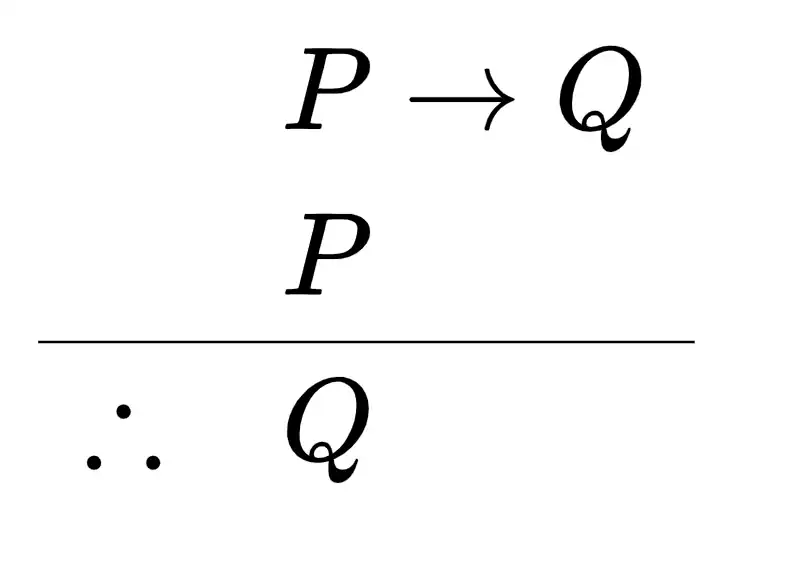

*Modus Tollens*

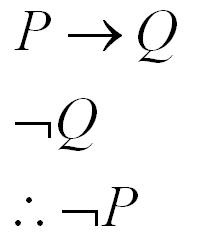

```python
psource(pl_resolution)
```

```
def pl_resolution(kb, alpha):
    """
    [Figure 7.12]
    Propositional-logic resolution: say if alpha follows from KB.
    >>> pl_resolution(horn_clauses_KB, A)
    True
    """
    clauses = kb.clauses + conjuncts(to_cnf(~alpha))
    new = set()
    while True:
        n = len(clauses)
        pairs = [(clauses[i], clauses[j])
                 for i in range(n) for j in range(i + 1, n)]
        for (ci, cj) in pairs:
            resolvents = pl_resolve(ci, cj)
            if False in resolvents:
                return True
            new = new.union(set(resolvents))
        if new.issubset(set(clauses)):
            return False
        for c in new:
            if c not in clauses:
                clauses.append(c)
```

```python
kb = PropKB()
```

For example we can provide for P => Q , P satisfying the implication will give us the conclusion Q

```python
kb.tell(P|'==>'|Q)
```

```python
kb.tell(P)
```

```python
kb.ask_if_true(P)
pl_resolution(kb, P)
```

```
True
```

Also for ~Q will give us the conclusion ~P

```python
kb.retract(P)
kb.tell(~Q)
```

```python
# kb.ask_if_true(~Q)
pl_resolution(kb, ~P)
```

```
True
```

# Tautologi with Entails

Keep in mind that for two symbols P and Q, P => Q is false only when P is True and Q is False. Example usage of tt_entails():

```python
tt_entails(P & Q, Q)
```

```
True
```

P & Q is True only when both P and Q are True. Hence, (P & Q) => Q is True

```python
tt_entails(P | Q, Q)
```

```
False
```

```python
tt_entails(P | Q, P)
```

```
False
```

If we know that P | Q is true, we cannot infer the truth values of P and Q. Hence (P | Q) => Q is False and so is (P | Q) => P.

```python
(A, B, C, D, E, F, G) = symbols('A, B, C, D, E, F, G')
tt_entails(A & (B | C) & D & E & ~(F | G), A & D & E & ~F & ~G)
```

```
True
```

We can see that for the KB to be true, A, D, E have to be True and F and G have to be False. Nothing can be said about B or C.

# Proof By Resolution (Decomposite Of Proposition)

We can handle a verification for certains logic's law

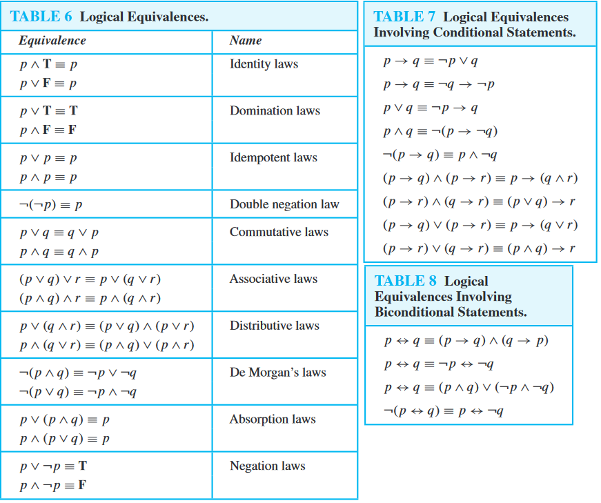

```python
to_cnf(P |'==>'| Q)
```

```
(Q | ~P)
```

```python
to_cnf(P |'<=>'| Q)
```

```
((P | ~Q) & (Q | ~P))
```

```python
to_cnf(~(P |'==>'| Q))
```

```
(~Q & P)
```

```python
to_cnf(P |'^'| Q)
```

```
((~P | P) & (Q | P) & (~P | ~Q) & (Q | ~Q))
```

```python
to_cnf(~(P & Q))
```

```
(~P | ~Q)
```

```python
to_cnf(~(P | Q))
```

```
(~P & ~Q)
```